# Run the cell below to generate the road map (do not modify it)

We also think about to split the train data set in 4 parts, each consists of length 5. The first 3 parts to act as the train data, the fourth part as the test data. But the length is too small to make the model accurate. We think that it is not quite good to make the train data set and test data set the same size, as in real life, the test data is kind of random. The algorithm need to be improved.

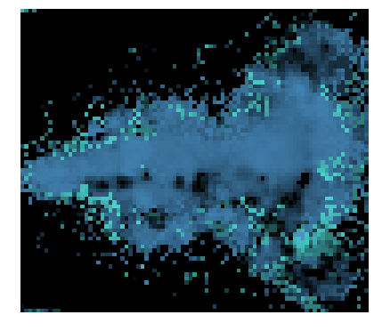

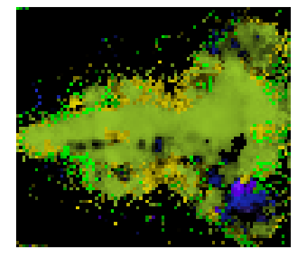

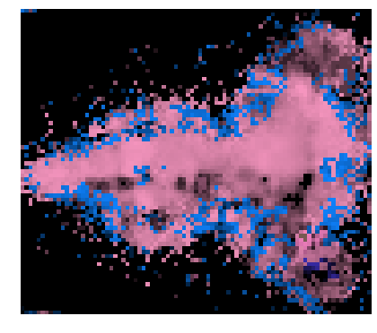

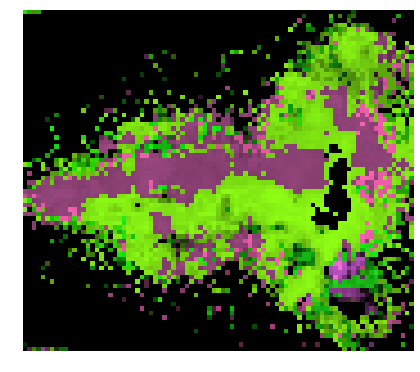

```python
def Draw_Image(models, test, test_series):
    for i in [2,3,4,5]:
        model = models[i]
        newClrs = optimize_color(model.centers)

        ## predict the center
        labels = test.map(lambda x: model.predict(x))
        imgLabels = np.array(labels.collect()).reshape(2,76,87)
#         draw_image(transform(newClrs, imgLabels[0,:,:]))

        ## draw the brainmap
        # build the mask
        sim = test_series.map(lambda x: similarity(model.centers, x))
        imgSim = sim.toarray()

        brainmap = transform(newClrs, imgLabels[0,:,:], mask=imgSim[0,:,:])
        draw_image(brainmap)

Draw_Image(filter_models, test, test_series)
```

Those figure are the results by models who are training by filtered dataset.

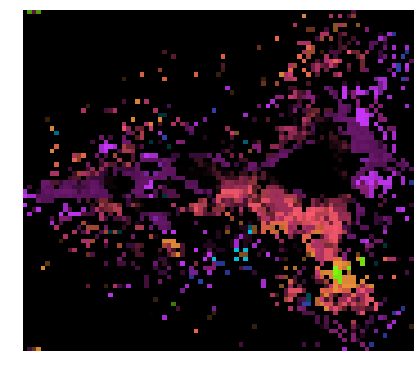

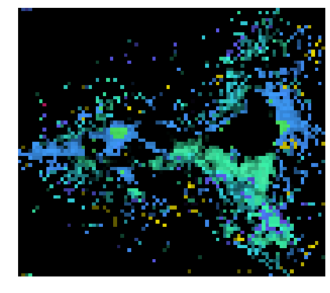

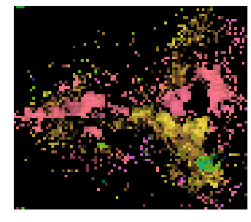

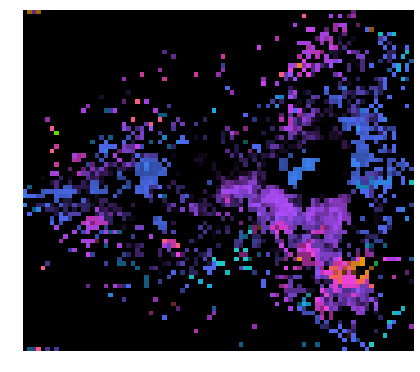

```python
train_1 = training_data.map(lambda x: x[0:5])
train_2 = training_data.map(lambda x: x[5:10])
train_3 = training_data.map(lambda x: x[10:15])
new_test = training_data.map(lambda x: x[15:20])

new_train = train_1 + train_2 + train_3
# new_train = training_data.map(lambda x: [x[0:5], x[5:10], x[10:15]])

new_models = list(map(lambda k: KMeans.train(new_train, k), ks))

new_test_series = data.map(lambda x: x[15:20])

Draw_Image(new_models, new_test, new_test_series)
```

These figures are obtained from training the model using the first 3 5-length train datasets. The number train set is 3 times of the test set. it is more reasonable, but it could bring some problems. The time series for each train set is short, we are not sure these can stand for the activity of the neurons. Maybe the whole process of the activity's length is longer than 5. Maybe some neuron activities are similar in the beginning, but totally different in the later part. Then it would lead to some mistakes.

[figure not shown]

#### Question 21

Is using K-Means the best choice for a clustering algorithm? Comment the choice and suggest alternatives. For example, look at [Mixture Models](https://en.wikipedia.org/wiki/Mixture_model) and, if you have time, propose an alternative clustering technique.

**NOTE**: Mixture models will be covered in the ASI course in greater detail.

# 4. Summary

We studied Thunder and its important methods to work with images, such as `Image`, `Series` and how to apply them to a use case. In the use case, we used the K-Means algorithm to cluster the neurons without prior knowledge of what a good choice of K could be. Subsequently, we introduced some techniques for improving the initially obtained results, such as removing noise and considering similarity.

# References

Some of the examples in this notebook are inspired from the [documentation of Thunder](http://docs.thunder-project.org/).